# elephant_in_the_room

## Basic Operations before stating the analysis

Loading the necessary packages for the project

```r
library(tidyverse) # Loads ggplot2, dplyr, tidyr, readr, purrr, tibble, and stringr
library(readxl)    # For reading Excel files
library(rvest)     # For web scraping
library(httr)      # For working with HTTP
library(rcrossref) # For using CrossRef's API
library(janitor)   # For cleaning data
library(reshape2)  # For reshaping data
library(igraph)    # For graphing
library(ggraph)    # For graphing
library(scales)    # For graphing
library(lubridate) # For time series work
library(gridExtra) # For Grid making
```

Loading the data-set sourced from Retraction Watch on 24-Dec-2023

```r
data<- read.csv("retraction_watch.csv")
```

Doing some wrangling of the data

```r
# Convert dates to POSIX format for the pupose of computation
data$OriginalPaperDate <- as.POSIXct(data$OriginalPaperDate, format = "%m/%d/%Y %H:%M")
data$RetractionDate <- as.POSIXct(data$RetractionDate, format = "%m/%d/%Y %H:%M")

# Compute the difference in months
data$DurationInMonths <- interval(start = data$OriginalPaperDate, end = data$RetractionDate) / months(1)

# Extract year from RetractionDate
data$RetractionYear <- year(data$RetractionDate)

#Creating Clean names
data<- data %>%
  clean_names()
```

Creating two separate subsets now - one for business related, and one for non business

```r
# Define business-related subjects
business_subjects <- c("Business - Management",
                       "Business - Economics",
                       "Business - Marketing",
                       "Business - General",
                       "Business - Manufacturing",
                       "Business - Accounting")

# Create a single pattern string for matching
pattern <- paste(business_subjects, collapse = "|")

# This is the Business related subjects
data_business <- data %>%
  filter(str_detect(subject, pattern))

# This is the Non Business related subjects
data_nonbusiness <- data %>%
  filter(!str_detect(subject, pattern))

data_temp<- data
```

Creating a set of correlation matrices

[figure not shown]

```r
# Step 1: Split the 'reason' field into individual reasons and remove the '+' prefix
reasons_list <- strsplit(gsub("^\\+", "", data_business$reason), ";")

# Step 2: Identify unique reasons
unique_reasons <- unique(unlist(reasons_list))

# Step 3: Create dummy variables for each unique reason
for(reason in unique_reasons) {
  data_business[[reason]] <- sapply(reasons_list, function(x) as.integer(reason %in% x))
}

# Select only dummy variables (and any other numeric variables you want to include)
numeric_data <- data_business[, sapply(data_business, is.numeric)]

# Compute the correlation matrix for numeric data
cor_matrix <- cor(numeric_data)

# Melt the correlation matrix for visualization
melted_cor_matrix <- reshape2::melt(cor_matrix)

# Define a threshold for displaying text
threshold <- 0.5

# Plot the correlation matrix
ggplot(data = melted_cor_matrix, aes(x=Var1, y=Var2, fill=value)) +
    geom_tile() +
    geom_text(aes(label = ifelse(abs(value) > threshold, round(value, 2), '')), color = "black", size = 2.5) +
    scale_fill_gradient2(low = "blue", high = "red", mid = "white",
                         midpoint = 0, limit = c(-1,1), space = "Lab",
                         name="Pearson\nCorrelation") +
    theme_minimal() +
    theme(axis.text.x = element_text(angle = 45, hjust = 1, size = 4),
          axis.text.y = element_text(size = 6),
          axis.title = element_blank()) +
    coord_fixed() # Ensure square cells
```

Condensing the co-plot with my own logic, for the business dataset

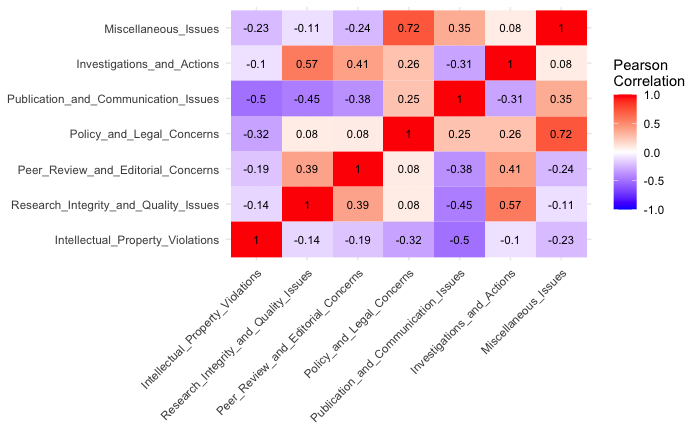

```r
# Define the patterns for each category
patterns <- list(
  Intellectual_Property_Violations = c("Plagiarism", "Duplication", "Euphemisms for Plagiarism", "False/Forged Authorship"),
  Research_Integrity_and_Quality_Issues = c("Not Reproducible", "Unreliable Results", "Error in Text", "Error in Analyses", "Error in Methods", "Error in Data", "Error in Results", "Fabrication", "Falsification", "Ethical Violations", "Issues About Data"),
  Peer_Review_and_Editorial_Concerns = c("Fake Peer Review", "Rogue Editor", "Investigation by Journal/Publisher", "Error by Journal/Publisher", "Objections by Author"),
  Policy_and_Legal_Concerns = c("Breach of Policy", "Issues about Referencing", "Legal Reasons", "Lack of Approval"),
  Publication_and_Communication_Issues = c("Withdrawal", "Limited or No Information", "Notice - Lack of", "Author Unresponsive", "Update of Prior Notice"),
  Investigations_and_Actions = c("Investigation by Third Party", "Doing the Right Thing"),
  Miscellaneous_Issues = c("Date of Retraction", "Randomly Generated Content", "Original Data not Provided", "Concerns About Image")
)

# Function to create dummy variables for categories based on the presence of certain patterns
create_dummy_vars <- function(df, patterns) {
  for (category in names(patterns)) {
    pattern <- patterns[[category]]
    df[[category]] <- as.integer(sapply(df$reason, function(x) {
      any(sapply(pattern, function(y) str_detect(x, regex(y, ignore_case = TRUE))))
    }))
  }
  return(df)
}

# Apply the function to the data frame
data_business <- create_dummy_vars(data_business, patterns)

# Ensure these columns exist in your data_business dataframe
selected_columns <- c("Intellectual_Property_Violations", "Research_Integrity_and_Quality_Issues",
                      "Peer_Review_and_Editorial_Concerns", "Policy_and_Legal_Concerns",
                      "Publication_and_Communication_Issues", "Investigations_and_Actions",
                      "Miscellaneous_Issues")

# Check if all selected columns are present in data_business
if(all(selected_columns %in% names(data_business))) {
    # Select only the specified dummy variable columns
    dummy_data <- data_business[, selected_columns]

    # Calculate the correlation matrix
    cor_matrix <- cor(dummy_data, use = "complete.obs") # use complete.obs to handle NA values

    # Melt the correlation matrix for visualization
    melted_cor_matrix <- reshape2::melt(cor_matrix)

    # Plot the correlation matrix with numbers
    ggplot(data = melted_cor_matrix, aes(x=Var1, y=Var2, fill=value)) +
        geom_tile() +
        geom_text(aes(label = round(value, 2)), color = "black", size = 3) +
        scale_fill_gradient2(low = "blue", high = "red", mid = "white",
                             midpoint = 0, limit = c(-1,1), space = "Lab",
                             name="Pearson\nCorrelation") +
        theme_minimal() +
        theme(axis.text.x = element_text(angle = 45, hjust = 1),
              axis.title = element_blank())

} else {
    stop("Not all specified columns exist in the dataframe.")
}
```

Condensing the co-plot with my own logic, for the non-business dataset

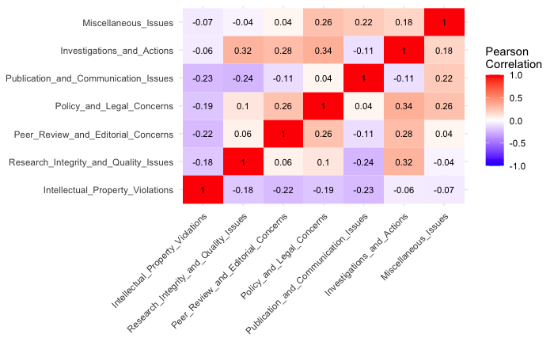

```r
# Apply the function to the data_nonbusiness dataframe
data_nonbusiness <- create_dummy_vars(data_nonbusiness, patterns)

# Ensure these columns exist in your data_nonbusiness dataframe
selected_columns <- c("Intellectual_Property_Violations", "Research_Integrity_and_Quality_Issues",
                      "Peer_Review_and_Editorial_Concerns", "Policy_and_Legal_Concerns",
                      "Publication_and_Communication_Issues", "Investigations_and_Actions",
                      "Miscellaneous_Issues")

# Check if all selected columns are present in data_nonbusiness
if(all(selected_columns %in% names(data_nonbusiness))) {
    # Select only the specified dummy variable columns
    dummy_data <- data_nonbusiness[, selected_columns]

    # Calculate the correlation matrix
    cor_matrix <- cor(dummy_data, use = "complete.obs") # use complete.obs to handle NA values

    # Melt the correlation matrix for visualization
    melted_cor_matrix <- reshape2::melt(cor_matrix)

    # Plot the correlation matrix with numbers
    ggplot(data = melted_cor_matrix, aes(x=Var1, y=Var2, fill=value)) +
        geom_tile() +
        geom_text(aes(label = round(value, 2)), color = "black", size = 3) +
        scale_fill_gradient2(low = "blue", high = "red", mid = "white",
                             midpoint = 0, limit = c(-1,1), space = "Lab",
                             name="Pearson\nCorrelation") +
        theme_minimal() +
        theme(axis.text.x = element_text(angle = 45, hjust = 1),
              axis.title = element_blank())

} else {
    stop("Not all specified columns exist in the dataframe.")
}
```

[figure not shown]

```r
# Step 1: Split the 'reason' field into individual reasons and remove the '+' prefix
reasons_list <- strsplit(gsub("^\\+", "", data_nonbusiness$reason), ";")

# Step 2: Identify unique reasons
unique_reasons <- unique(unlist(reasons_list))

# Step 3: Create dummy variables for each unique reason
for(reason in unique_reasons) {
  data_nonbusiness[[reason]] <- sapply(reasons_list, function(x) as.integer(reason %in% x))
}

# Select only dummy variables (and any other numeric variables you want to include)
numeric_data <- data_nonbusiness[, sapply(data_nonbusiness, is.numeric)]

# Compute the correlation matrix for numeric data
cor_matrix <- cor(numeric_data)

# Melt the correlation matrix for visualization
melted_cor_matrix <- reshape2::melt(cor_matrix)

# Define a threshold for displaying text
threshold <- 0.5

# Plot the correlation matrix
ggplot(data = melted_cor_matrix, aes(x=Var1, y=Var2, fill=value)) +
    geom_tile() +
    geom_text(aes(label = ifelse(abs(value) > threshold, round(value, 2), '')), color = "black", size = 2.5) +
    scale_fill_gradient2(low = "blue", high = "red", mid = "white",
                         midpoint = 0, limit = c(-1,1), space = "Lab",
                         name="Pearson\nCorrelation") +
    theme_minimal() +
    theme(axis.text.x = element_text(angle = 45, hjust = 1, size = 4),
          axis.text.y = element_text(size = 6),
          axis.title = element_blank()) +
    coord_fixed() # Ensure square cells
```

Trying to plot how retractions have been in Non Management disciplines

```r
# Prepare data
yearly_data <- data_nonbusiness %>%
  group_by(retraction_year) %>%
  summarize(average_duration = mean(duration_in_months, na.rm = TRUE),
            retraction_count = n())

# Normalize the RetractionCount for better visualization
max_duration <- max(yearly_data$average_duration, na.rm = TRUE)
max_count <- max(yearly_data$retraction_count, na.rm = TRUE)
yearly_data$NormalizedCount <- yearly_data$retraction_count / max_count * max_duration

retractions_nonmanagement<- ggplot(yearly_data, aes(x = retraction_year)) +
  geom_line(aes(y = average_duration, group = 1), color = "blue") +
  geom_point(aes(y = average_duration), color = "blue") +
  geom_bar(aes(y = NormalizedCount), stat = "identity", fill = "red", alpha = 0.5) +
    scale_x_continuous(limits = c(1990, NA)) +  # Limiting x-axis to start from 1970+

  scale_y_continuous(name = "Average Duration in Months",
                     sec.axis = sec_axis(~ . * max_count / max_duration,
                                         name = "Number of Retractions")) +
  labs(title = "Retractions over the Years: Duration and Count (Non Management Disciplines)",
       x = "Retraction Year") +
  theme_minimal()
```

Trying to plot how retractions have been in Management disciplines

```r
# Prepare data
yearly_data <- data_business %>%
  group_by(retraction_year) %>%
  summarize(average_duration = mean(duration_in_months, na.rm = TRUE),
            retraction_count = n())

# Normalize the RetractionCount for better visualization
max_duration <- max(yearly_data$average_duration, na.rm = TRUE)
max_count <- max(yearly_data$retraction_count, na.rm = TRUE)
yearly_data$NormalizedCount <- yearly_data$retraction_count / max_count * max_duration

retractions_management<- ggplot(yearly_data, aes(x = retraction_year)) +
  geom_line(aes(y = average_duration, group = 1), color = "blue") +
  geom_point(aes(y = average_duration), color = "blue") +
  geom_bar(aes(y = NormalizedCount), stat = "identity", fill = "red", alpha = 0.5) +
    scale_x_continuous(limits = c(1990, NA)) +  # Limiting x-axis to start from 1970+

  scale_y_continuous(name = "Average Duration in Months",
                     sec.axis = sec_axis(~ . * max_count / max_duration,
                                         name = "Number of Retractions")) +
  labs(title = "Retractions over the Years: Duration and Count (Management Disciplines)",
       x = "Retraction Year") +
  theme_minimal()
```

Displaying the plot

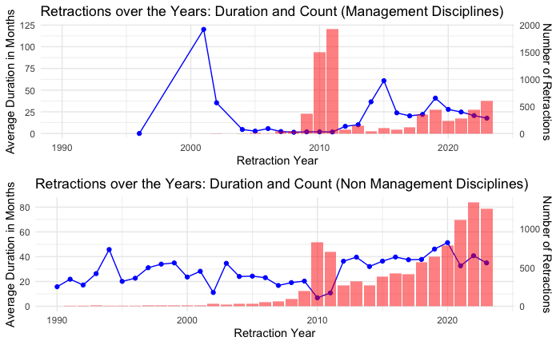

```r
grid.arrange(retractions_management, retractions_nonmanagement, ncol = 1)
```

Trying to understand the distribution of subjects now.

Distribution of Subjects - Non Management Subjects

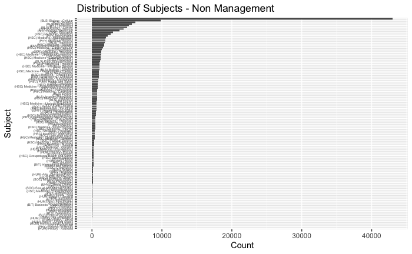

```r
# Separate the subjects into individual rows
data_subjects <- data_nonbusiness %>%
                 separate_rows(subject, sep = ";\\s*")

# Count the occurrences of each subject
subject_count <- data_subjects %>%
                 count(subject, sort = TRUE)

# Create a horizontal bar chart
ggplot(subject_count, aes(y = reorder(subject, n), x = n)) +
    geom_bar(stat = "identity", position = "dodge") +
    theme(axis.text.y = element_text(size = 4)) +
    labs(y = "Subject", x = "Count", title = "Distribution of Subjects - Non Management")
```

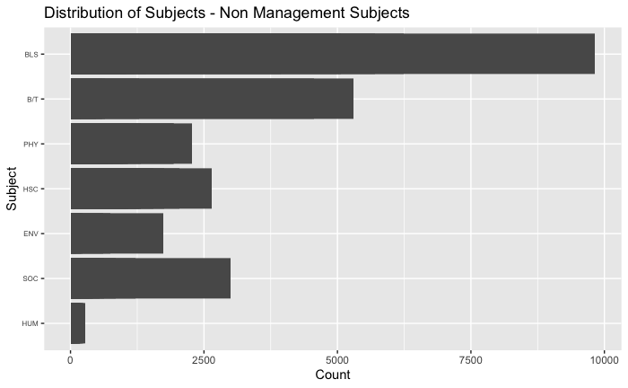

```r
# Rename the subject to the broader theme that's written in the brackets
subject_count <- subject_count %>%
  mutate(subject = str_match(subject, "\\(([^)]+)\\)")[,2])

# Remove NA values that might have been introduced if there were subjects without brackets
subject_count <- subject_count %>%
  filter(!is.na(subject))

# Create a horizontal bar chart
ggplot(subject_count, aes(y = reorder(subject, n), x = n)) +
  geom_bar(stat = "identity", position = "dodge") +
  theme(axis.text.y = element_text(size = 6)) +
  labs(y = "Subject", x = "Count", title = "Distribution of Subjects - Non Management Subjects")
```

Distribution of Subjects - Management Subjects

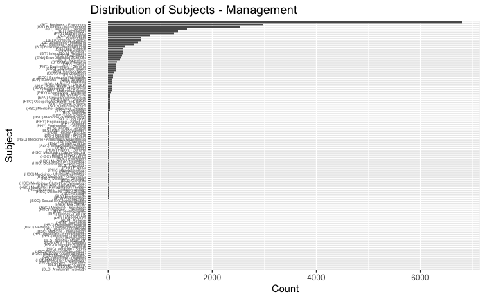

```r
# Separate the subjects into individual rows
data_subjects <- data_business %>%
                 separate_rows(subject, sep = ";\\s*")

# Count the occurrences of each subject
subject_count <- data_subjects %>%
                 count(subject, sort = TRUE)

# Create a horizontal bar chart
ggplot(subject_count, aes(y = reorder(subject, n), x = n)) +
    geom_bar(stat = "identity", position = "dodge") +
    theme(axis.text.y = element_text(size = 4)) +
    labs(y = "Subject", x = "Count", title = "Distribution of Subjects - Management")
```

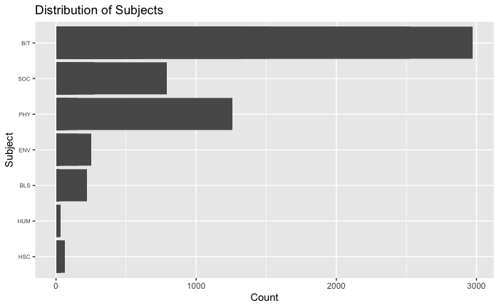

```r
# Rename the subject to the broader theme that's written in the brackets
subject_count <- subject_count %>%
  mutate(subject = str_match(subject, "\\(([^)]+)\\)")[,2])

# Remove NA values that might have been introduced if there were subjects without brackets
subject_count <- subject_count %>%
  filter(!is.na(subject))

# Create a horizontal bar chart
ggplot(subject_count, aes(y = reorder(subject, n), x = n)) +
  geom_bar(stat = "identity", position = "dodge") +
  theme(axis.text.y = element_text(size = 6)) +
  labs(y = "Subject", x = "Count", title = "Distribution of Subjects")
```

Note: You see that there are other non management areas also linked here. That’s because a lot of the papers have also been listed as science, environment and sociology, etc.

Trying to understand the distribution of countries now

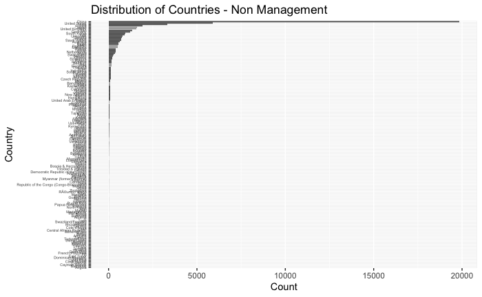

```r
# Separate the subjects into individual rows
data_country <- data_nonbusiness %>%
                 separate_rows(country, sep = ";\\s*")

# Count the occurrences of each subject
country_count <- data_country %>%
                 count(country, sort = TRUE)

# Create a horizontal bar chart
ggplot(country_count, aes(y = reorder(country, n), x = n)) +
    geom_bar(stat = "identity", position = "dodge") +
    theme(axis.text.y = element_text(size = 4)) +
    labs(y = "Country", x = "Count", title = "Distribution of Countries - Non Management")
```

```r
length(unique(country_count$country))
```

```
[1] 173
```

There appear to be authors from 173 countries participating here.

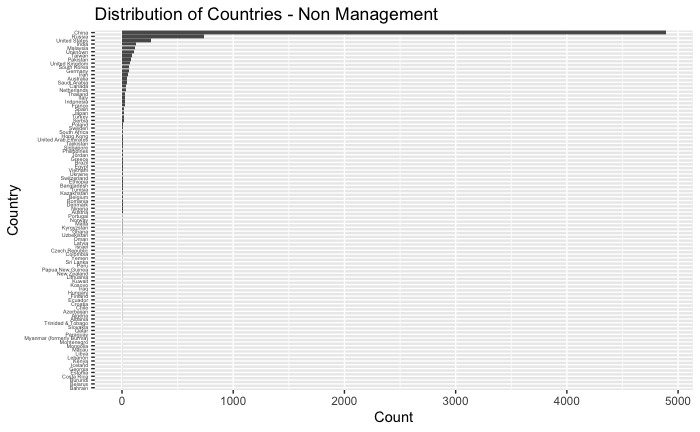

```r
# Separate the subjects into individual rows
data_country <- data_business %>%
                 separate_rows(country, sep = ";\\s*")

# Count the occurrences of each subject
country_count <- data_country %>%
                 count(country, sort = TRUE)

# Create a horizontal bar chart
ggplot(country_count, aes(y = reorder(country, n), x = n)) +
    geom_bar(stat = "identity", position = "dodge") +
    theme(axis.text.y = element_text(size = 4)) +
    labs(y = "Country", x = "Count", title = "Distribution of Countries - Non Management")
```

```r
NA
NA
```

```r
length(unique(country_count$country))
```

```
[1] 94
```

There appear to be authors from 94 countries participating here.

Trying to understand the distribution of institutions now

```r
# Separate the subjects into individual rows
data_institution <- data_nonbusiness %>%
                 separate_rows(institution, sep = ";\\s*")

# Count the occurrences of each subject
institution_count <- data_institution %>%
                 count(institution, sort = TRUE)

length(unique(institution_count$institution))
```

```
[1] 77610
```

There appear to be authors from 77610 institutions participated here.

```r
# Separate the subjects into individual rows
data_institution <- data_business %>%
                 separate_rows(institution, sep = ";\\s*")

# Count the occurrences of each subject
institution_count <- data_institution %>%
                 count(institution, sort = TRUE)

length(unique(institution_count$institution))
```

```
[1] 8240
```

There appear to be authors from 8240 institutions participated here.

Checking on repeat offenders

```r
# Separate the subjects into individual rows
data_author <- data_nonbusiness %>%
                 separate_rows(author, sep = ";\\s*")

# Count the occurrences of each subject
author_count <- data_author %>%
                 count(author, sort = TRUE)

author_count_nonbusiness <-author_count

length(unique(author_count$author))
```

```
[1] 122573
```

There are about 1,22,573 unique authors in the non business dataset.

```r
length(unique(author_count$author))/length(data_nonbusiness$record_id)
```

```
[1] 2.850535
```

```r
length(unique(author_count$author))/length(data_nonbusiness$record_id)
```

```
[1] 2.850535
```

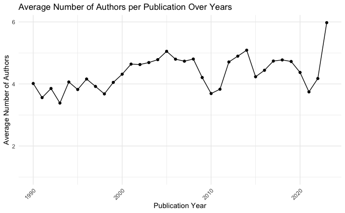

```r
# Step 1: Add a column with the number of authors per publication
data_nonbusiness <- data_nonbusiness %>%
  mutate(
    num_authors = sapply(strsplit(as.character(author), ";"), length),
    publication_year = year(original_paper_date)
  )

# Step 2: Group by publication year and calculate the average number of authors
average_authors_per_year <- data_nonbusiness %>%
  group_by(publication_year) %>%
  summarise(average_authors = mean(num_authors, na.rm = TRUE))

# Plotting the average number of authors per year
ggplot(average_authors_per_year, aes(x = publication_year, y = average_authors)) +
  geom_line() +  # Line plot
  geom_point() + # Adding points to each year
  theme_minimal() +
  labs(
    title = "Average Number of Authors per Publication Over Years",
    x = "Publication Year",
    y = "Average Number of Authors"
  ) +
  theme(
    axis.text.x = element_text(angle = 45, hjust = 1) # Adjusting x-axis labels for better readability
  )+
    scale_x_continuous(limits = c(1990, max(average_authors_per_year$publication_year))) # Limiting x-axis from 1980 onward
```

```r
NA
NA
```

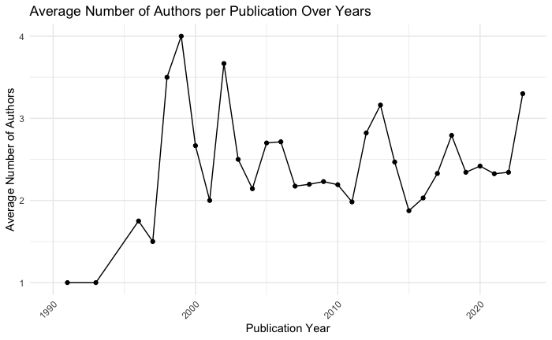

```r
# Step 1: Add a column with the number of authors per publication
data_business <- data_business %>%
  mutate(
    num_authors = sapply(strsplit(as.character(author), ";"), length),
    publication_year = year(original_paper_date)
  )

# Step 2: Group by publication year and calculate the average number of authors
average_authors_per_year <- data_business %>%
  group_by(publication_year) %>%
  summarise(average_authors = mean(num_authors, na.rm = TRUE))

# Plotting the average number of authors per year
ggplot(average_authors_per_year, aes(x = publication_year, y = average_authors)) +
  geom_line() +  # Line plot
  geom_point() + # Adding points to each year
  theme_minimal() +
  labs(
    title = "Average Number of Authors per Publication Over Years",
    x = "Publication Year",
    y = "Average Number of Authors"
  ) +
  theme(
    axis.text.x = element_text(angle = 45, hjust = 1) # Adjusting x-axis labels for better readability
  )+
    scale_x_continuous(limits = c(1990, max(average_authors_per_year$publication_year))) # Limiting x-axis from 1980 onward
```

```r
NA
NA
```

Preparing a joint plot

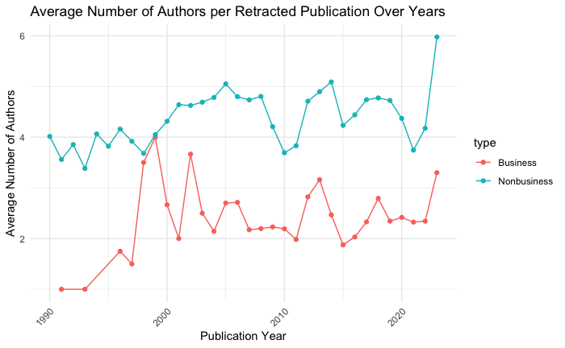

```r
# Prepare nonbusiness data
data_nonbusiness <- data_nonbusiness %>%
  mutate(
    num_authors = sapply(strsplit(as.character(author), ";"), length),
    publication_year = year(original_paper_date),
    type = "Nonbusiness"
  )

# Prepare business data
data_business <- data_business %>%
  mutate(
    num_authors = sapply(strsplit(as.character(author), ";"), length),
    publication_year = year(original_paper_date),
    type = "Business"
  )

# Combine the datasets
combined_data <- bind_rows(data_nonbusiness, data_business)

# Group by publication year and type, then calculate the average number of authors
average_authors_per_year_type <- combined_data %>%
  group_by(publication_year, type) %>%
  summarise(average_authors = mean(num_authors, na.rm = TRUE))
# Plotting the average number of authors per year for both types
ggplot(average_authors_per_year_type, aes(x = publication_year, y = average_authors, color = type)) +
  geom_line() +  # Line plot
  geom_point() + # Adding points to each year
  theme_minimal() +
  labs(
    title = "Average Number of Authors per Retracted Publication Over Years",
    x = "Publication Year",
    y = "Average Number of Authors"
  ) +
  theme(
    axis.text.x = element_text(angle = 45, hjust = 1) # Adjusting x-axis labels for better readability
  )+
  scale_x_continuous(limits = c(1990, max(average_authors_per_year_type$publication_year))) #
```

Doing something similar for number of institutions

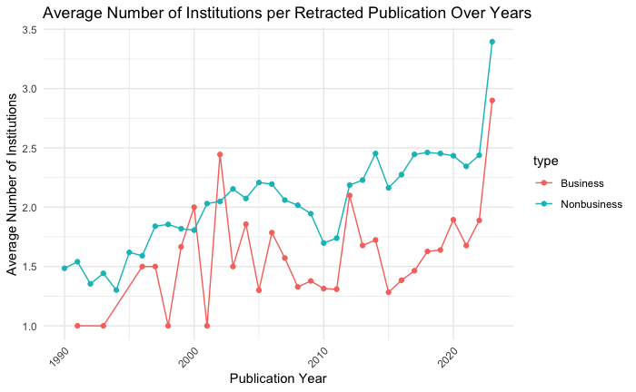

```r
# Prepare nonbusiness data with the number of institutions
data_nonbusiness <- data_nonbusiness %>%
  mutate(
    num_institutions = sapply(strsplit(as.character(institution), ";"), length),  # Count institutions
    publication_year = year(original_paper_date),
    type = "Nonbusiness"
  )

# Prepare business data with the number of institutions
data_business <- data_business %>%
  mutate(
    num_institutions = sapply(strsplit(as.character(institution), ";"), length),  # Count institutions
    publication_year = year(original_paper_date),
    type = "Business"
  )

# Combine the datasets
combined_data <- bind_rows(data_nonbusiness, data_business)

# Group by publication year and type, then calculate the average number of institutions
average_institutions_per_year_type <- combined_data %>%
  group_by(publication_year, type) %>%
  summarise(average_institutions = mean(num_institutions, na.rm = TRUE))
# Plotting the average number of institutions per year for both types
ggplot(average_institutions_per_year_type, aes(x = publication_year, y = average_institutions, color = type)) +
  geom_line() +  # Line plot
  geom_point() + # Adding points to each year
  theme_minimal() +
  labs(
    title = "Average Number of Institutions per Retracted Publication Over Years",
    x = "Publication Year",
    y = "Average Number of Institutions"
  ) +
  theme(
    axis.text.x = element_text(angle = 45, hjust = 1) # Adjusting x-axis labels for better readability
  )+
  scale_x_continuous(limits = c(1990, max(average_institutions_per_year_type$publication_year))) # Limiting x-axis
```

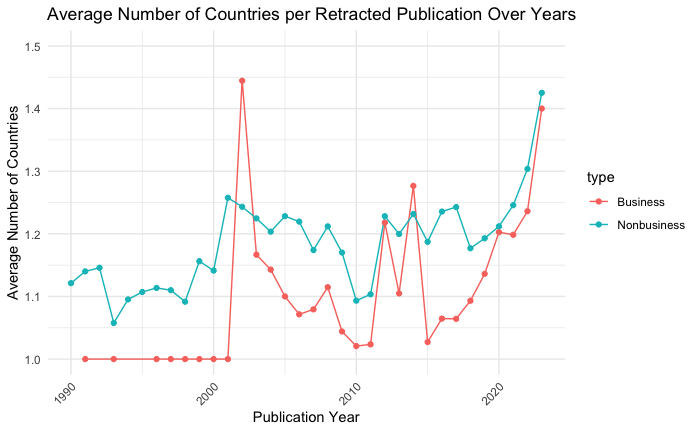

```r
# Prepare nonbusiness data with the number of countries
data_nonbusiness <- data_nonbusiness %>%
  mutate(
    num_countries = sapply(strsplit(as.character(country), ";"), length),  # Count countries
    publication_year = year(original_paper_date),
    type = "Nonbusiness"
  )

# Prepare business data with the number of countries
data_business <- data_business %>%
  mutate(
    num_countries = sapply(strsplit(as.character(country), ";"), length),  # Count countries
    publication_year = year(original_paper_date),
    type = "Business"
  )

# Combine the datasets
combined_data <- bind_rows(data_nonbusiness, data_business)

# Group by publication year and type, then calculate the average number of countries
average_countries_per_year_type <- combined_data %>%
  group_by(publication_year, type) %>%
  summarise(average_countries = mean(num_countries, na.rm = TRUE))
# Plotting the average number of countries per year for both types
ggplot(average_countries_per_year_type, aes(x = publication_year, y = average_countries, color = type)) +
  geom_line() +  # Line plot
  geom_point() + # Adding points to each year
  theme_minimal() +
  labs(
    title = "Average Number of Countries per Retracted Publication Over Years",
    x = "Publication Year",
    y = "Average Number of Countries"
  ) +
  theme(
    axis.text.x = element_text(angle = 45, hjust = 1) # Adjusting x-axis labels for better readability
  )+
  scale_x_continuous(limits = c(1990, max(average_countries_per_year_type$publication_year))) +
    scale_y_continuous(limits = c(1, 1.5))
```

What is pending: 1. Eigen vector centrality 2. Cor plots for reasons? 3. Can I put the retractions data on a map to show where the retractions have been coming from? 4. Time series clustering?

```r
# Separate the authors and associate them with broader subjects and years
author_data <- data_temp %>%
  mutate(publication_year = year(original_paper_date),
         broader_subject = str_extract(subject, "\\(([^)]+)\\)")) %>%
  select(author, broader_subject, publication_year) %>%
  separate_rows(author, sep = ";\\s*") %>%
  filter(broader_subject != "" & !is.na(broader_subject))

# Assuming each row in author_data is unique to an article, if not, ensure uniqueness
author_data <- author_data %>% distinct()
```

```r
# Create a data frame for edges (co-authorships)
edges <- author_data %>%
  group_by(publication_year) %>%
  summarise(authors = list(unique(author))) %>%
  filter(length(authors) > 1) %>%
  unnest(authors) %>%
  combn(2, simplify = FALSE) %>%
  lapply(function(pair) data.frame(from = pair[1], to = pair[2])) %>%
  bind_rows()

# Create a graph from the edge list
author_graph <- graph_from_data_frame(edges, directed = FALSE)
```

```r
eig_centrality <- eigen_centrality(author_graph)$vector
names(eig_centrality) <- V(author_graph)$name
```

```r
centrality_subjects <- author_data %>%
  distinct(author, broader_subject) %>%
  mutate(eig_centrality = eig_centrality[author])

# Aggregating centrality scores by broader subject
subject_centrality <- centrality_subjects %>%
  group_by(broader_subject) %>%
  summarise(avg_centrality = mean(eig_centrality, na.rm = TRUE))
```

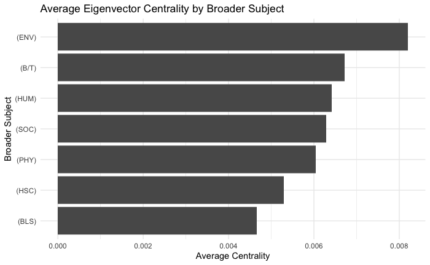

```r
library(ggplot2)

ggplot(subject_centrality, aes(x = reorder(broader_subject, avg_centrality), y = avg_centrality)) +
  geom_bar(stat = "identity") +
  theme_minimal() +
  labs(title = "Average Eigenvector Centrality by Broader Subject", x = "Broader Subject", y = "Average Centrality") +
  coord_flip()  # For horizontal bars
```

Trying something random with time dimension

```r
author_data <- data_temp %>%
  mutate(
    publication_year = year(original_paper_date),
    broader_subject = str_extract(subject, "\\(([^)]+)\\)")
  ) %>%
  select(record_id, author, broader_subject, publication_year) %>%
  separate_rows(author, sep = ";\\s*") %>%
  filter(broader_subject != "" & !is.na(broader_subject))


# Initialize a list to store centrality data for each year
yearly_centrality_data <- list()

unique_years <- unique(author_data$publication_year)

for(year in unique_years) {
    year_data <- author_data %>% filter(publication_year == year)

    edges <- year_data %>%
        group_by(record_id) %>%
        summarise(authors = list(unique(author))) %>%
        filter(length(authors) > 1) %>%
        unnest(authors) %>%
        combn(2, simplify = FALSE) %>%
        lapply(function(pair) data.frame(from = pair[1], to = pair[2])) %>%
        bind_rows()

    graph <- graph_from_data_frame(edges, directed = FALSE)

    centrality <- eigen_centrality(graph)$vector
    names(centrality) <- V(graph)$name

    yearly_centrality_data[[as.character(year)]] <- centrality
}
```

```r
centrality_subject_year <- author_data %>%
    mutate(eig_centrality = map2(publication_year, author, ~yearly_centrality_data[[as.character(.x)]][.y])) %>%
    unnest(eig_centrality)
```

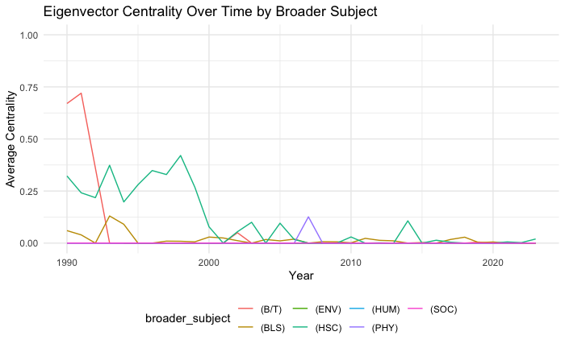

```r
# Aggregate centrality scores
subject_year_centrality <- centrality_subject_year %>%
    group_by(broader_subject, publication_year) %>%
    summarise(avg_centrality = mean(eig_centrality, na.rm = TRUE))
ggplot(subject_year_centrality, aes(x = publication_year, y = avg_centrality, group = broader_subject, color = broader_subject)) +
    geom_line() +
    scale_x_continuous(limits = c(1990, max(subject_year_centrality$publication_year))) +  # Set x-axis limits
    theme_minimal() +
    labs(title = "Eigenvector Centrality Over Time by Broader Subject",
         x = "Year",
         y = "Average Centrality") +
    theme(legend.position = "bottom")
```

```r
NA
NA
```

Questions to think about 3. Are there some areas/subjects more prone to retractions?

1. Are there retractions in higher quality journals? Is this problem just there in low quality journals?

Finding a solution to this now:

Getting the ABDC dataset

```r
abdc<- read.csv("abdc.csv")

#Filtering to latest abdc rankings only from 2022
abdc<- abdc %>%
  filter(
    year == 2022
  )
```

```r
# Merging the two datasets
data_business_temp <- inner_join(data_business, abdc)
#getting the journals that are not listed- complementart set
journals_not_listed <- data_business$journal[!data_business$journal %in% data_business_temp$journal]
journals_not_listed_df <- data.frame(journal = journals_not_listed)
```

Checking distribution

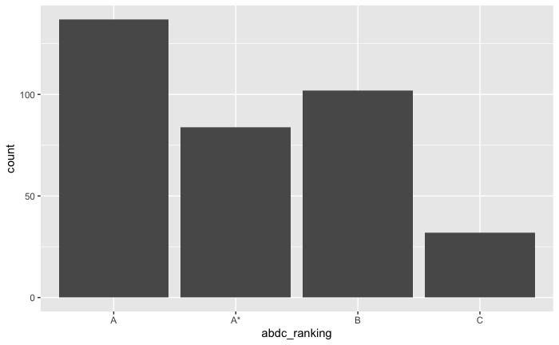

```r
# Plot the histogram of reasons
ggplot(data_business_temp, aes(x = abdc_ranking)) +
  geom_histogram(stat = "count")
```

It appears that a lot of A*s still get retractions. It is fully possible that the A*s and As have a much better policy to police the retractions.

Just looking at reasons for the retractions

```r
library(dplyr)

# Identify the reason columns
reason_columns <- grep("^\\+", names(data_business_temp), value = TRUE)

# Summarize the data to get counts of each reason for each abdc_ranking
top_reasons <- data_business_temp %>%
  select(abdc_ranking, all_of(reason_columns)) %>%
  gather(key = "reason", value = "count", -abdc_ranking) %>%
  group_by(abdc_ranking, reason) %>%
  summarise(total = sum(count)) %>%
  arrange(abdc_ranking, desc(total)) %>%
  group_by(abdc_ranking) %>%
  filter(rank(-total) <= 5)  # Select top 5 reasons for each abdc_ranking
# View the results
print(top_reasons)
```

| abdc_ranking | reason | total |
| --- | --- | --- |
| A | +Investigation by Journal/Publisher | 36 |
| A | +Misconduct by Author | 25 |
| A | +Investigation by Company/Institution | 24 |
| A | +Misconduct - Official Investigation/Finding | 23 |
| A | +Fake Peer Review | 14 |
| A* | +Investigation by Company/Institution | 21 |
| A* | +Misconduct - Official Investigation/Finding | 18 |
| A* | +Investigation by Journal/Publisher | 17 |
| A* | +Misconduct by Author | 17 |
| A* | +Unreliable Results | 17 |

[output cut: 8 more lines]

These results are interesting and team needs to see

One reason we are seeing a lot of journals not listed I think is because a lot of them are engineering ones that also list as management. There are also those that are not journal articles but conference papers, and other scholarly worlds.

2. Are inter disciplinary works prone to more retractions

```r
# Step 1: Add a column with the number of disciplines per publication

data_nonbusiness <- data_nonbusiness %>%
  mutate(
    num_subjects = sapply(strsplit(as.character(subject), ";"), length),
    num_unique_disciplines = sapply(
      strsplit(as.character(subject), ";"),
      function(subjects) {
        # Extract disciplines
        disciplines <- unlist(lapply(subjects, function(x) str_extract_all(x, "\\(([^()]*)\\)")))
        # Flatten the list and remove NA
        disciplines <- unlist(disciplines)
        disciplines <- disciplines[!is.na(disciplines)]
        # Count unique disciplines
        length(unique(disciplines))
      }
    )
  )

# mirroring
data_business <- data_business %>%
  mutate(
    num_subjects = sapply(strsplit(as.character(subject), ";"), length),
    num_unique_disciplines = sapply(
      strsplit(as.character(subject), ";"),
      function(subjects) {
        # Extract disciplines
        disciplines <- unlist(lapply(subjects, function(x) str_extract_all(x, "\\(([^()]*)\\)")))
        # Flatten the list and remove NA
        disciplines <- unlist(disciplines)
        disciplines <- disciplines[!is.na(disciplines)]
        # Count unique disciplines
        length(unique(disciplines))
      }
    )
  )
```

Retractions Over Time by Number of Disciplines - Non Business

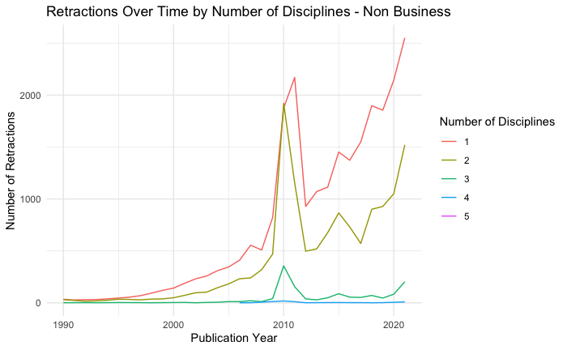

```r
# Aggregate data
retractions_over_time <- data_nonbusiness %>%
  group_by(publication_year, num_unique_disciplines) %>%
  summarise(retractions = n(), .groups = 'drop')

# Create the plot
ggplot(retractions_over_time, aes(x = publication_year, y = retractions, color = as.factor(num_unique_disciplines))) +
  geom_line() +
  labs(title = "Retractions Over Time by Number of Disciplines - Non Business",
       x = "Publication Year",
       y = "Number of Retractions",
       color = "Number of Disciplines") +
  theme_minimal() +
    scale_x_continuous(limits = c(1990, 2021)) #
```

```r
NA
NA
```

Retractions Over Time by Number of Disciplines - Business

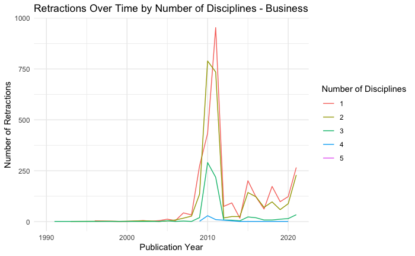

```r
retractions_over_time <- data_business %>%
  group_by(publication_year, num_unique_disciplines) %>%
  summarise(retractions = n(), .groups = 'drop')

# Create the plot
ggplot(retractions_over_time, aes(x = publication_year, y = retractions, color = as.factor(num_unique_disciplines))) +
  geom_line() +
  labs(title = "Retractions Over Time by Number of Disciplines - Business",
       x = "Publication Year",
       y = "Number of Retractions",
       color = "Number of Disciplines") +
  theme_minimal() +
    scale_x_continuous(limits = c(1990, 2021)) #
```

```r
NA
NA
```

Retractions Over Time by Number of Subjects - Non Business

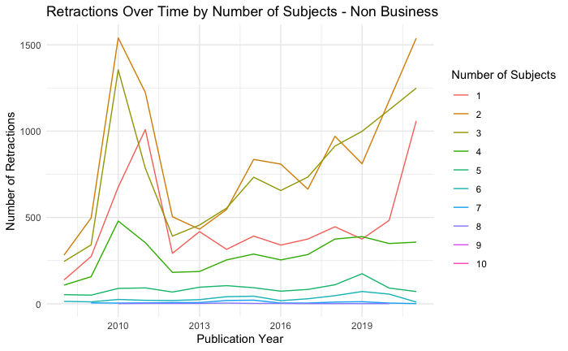

```r
# Aggregate data
retractions_over_time <- data_nonbusiness %>%
  group_by(publication_year, num_subjects) %>%
  summarise(retractions = n(), .groups = 'drop')

# Create the plot
ggplot(retractions_over_time, aes(x = publication_year, y = retractions, color = as.factor(num_subjects))) +
  geom_line() +
  labs(title = "Retractions Over Time by Number of Subjects - Non Business",
       x = "Publication Year",
       y = "Number of Retractions",
       color = "Number of Subjects") +
  theme_minimal() +
    scale_x_continuous(limits = c(2008, 2021)) #
```

```r
NA
NA
```

Retractions Over Time by Number of Subjects - Business

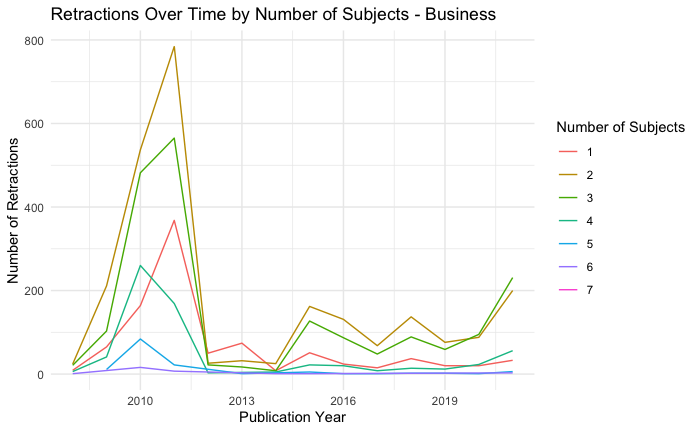

```r
retractions_over_time <- data_business %>%
  group_by(publication_year, num_subjects) %>%
  summarise(retractions = n(), .groups = 'drop')

# Create the plot
ggplot(retractions_over_time, aes(x = publication_year, y = retractions, color = as.factor(num_subjects))) +
  geom_line() +
  labs(title = "Retractions Over Time by Number of Subjects - Business",
       x = "Publication Year",
       y = "Number of Retractions",
       color = "Number of Subjects") +
  theme_minimal() +
    scale_x_continuous(limits = c(2008, 2021)) #
```

```r
NA
NA
NA
```

We can’t really comment on this since we do not have the overall non retracted data. But I think we can safely say that number of papers listed in single category would be >> than number of papers listed in multiple categories ..

so in % terms, the 2 cat thing would be more pronounced. Same with 3,4,5, etc.

Retractions Over Time by Number of Authors - Non Business

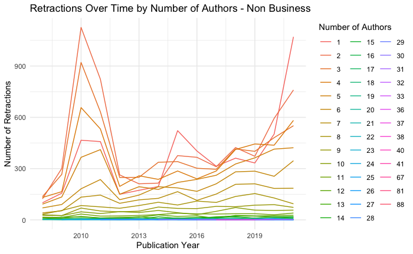

```r
# Aggregate data
retractions_over_time_authors <- data_nonbusiness %>%
  group_by(publication_year, num_authors) %>%
  summarise(retractions = n(), .groups = 'drop')

# Create the plot
ggplot(retractions_over_time_authors, aes(x = publication_year, y = retractions, color = as.factor(num_authors))) +
  geom_line() +
  labs(title = "Retractions Over Time by Number of Authors - Non Business",
       x = "Publication Year",
       y = "Number of Retractions",
       color = "Number of Authors") +
  theme_minimal() +
      scale_x_continuous(limits = c(2008, 2021)) #
```

```r
NA
NA
```

Retractions Over Time by Number of Authors - Business

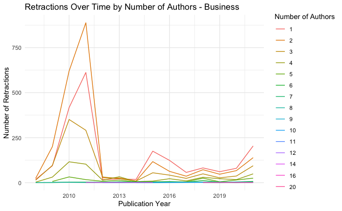

```r
# Aggregate data
retractions_over_time_authors <- data_business %>%
  group_by(publication_year, num_authors) %>%
  summarise(retractions = n(), .groups = 'drop')

# Create the plot
ggplot(retractions_over_time_authors, aes(x = publication_year, y = retractions, color = as.factor(num_authors))) +
  geom_line() +
  labs(title = "Retractions Over Time by Number of Authors - Business",
       x = "Publication Year",
       y = "Number of Retractions",
       color = "Number of Authors") +
  theme_minimal() +
      scale_x_continuous(limits = c(2008, 2021)) #
```

Retractions Over Time by Number of Institutions - Non Business

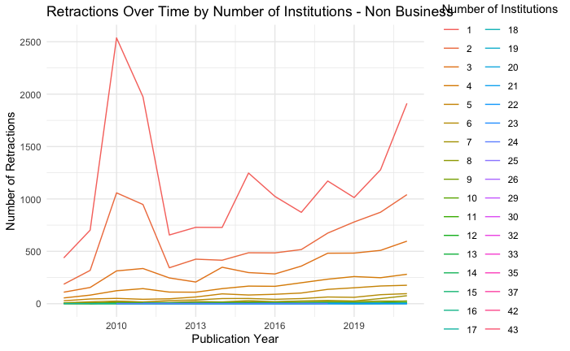

```r
# Aggregate data
retractions_over_time_institutions <- data_nonbusiness %>%
  group_by(publication_year, num_institutions) %>%
  summarise(retractions = n(), .groups = 'drop')

# Create the plot
ggplot(retractions_over_time_institutions, aes(x = publication_year, y = retractions, color = as.factor(num_institutions))) +
  geom_line() +
  labs(title = "Retractions Over Time by Number of Institutions - Non Business",
       x = "Publication Year",
       y = "Number of Retractions",
       color = "Number of Institutions") +
  theme_minimal() +
        scale_x_continuous(limits = c(2008, 2021)) #
```

Retractions Over Time by Number of Institutions - Business

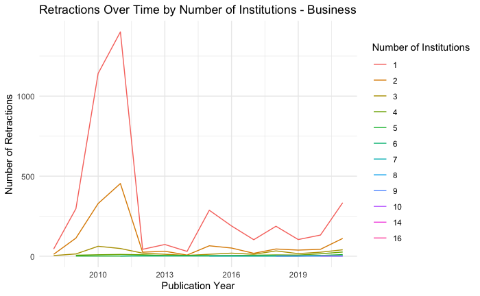

```r
# Aggregate data
retractions_over_time_institutions <- data_business %>%
  group_by(publication_year, num_institutions) %>%
  summarise(retractions = n(), .groups = 'drop')

# Create the plot
ggplot(retractions_over_time_institutions, aes(x = publication_year, y = retractions, color = as.factor(num_institutions))) +
  geom_line() +
  labs(title = "Retractions Over Time by Number of Institutions - Business",
       x = "Publication Year",
       y = "Number of Retractions",
       color = "Number of Institutions") +
  theme_minimal() +
        scale_x_continuous(limits = c(2008, 2021)) #
```

Ideas after discussion with Manish on 02-Jan-2024

```r
# Prepare the data
data_business <- data_business %>%
  select(subject, record_id) %>%
  filter(!is.na(subject)) %>%
  mutate(subject = strsplit(as.character(subject), ";")) %>%
  unnest(subject) %>%
  group_by(subject) %>%
  mutate(freq = n()) %>%
  ungroup()
```

```r
# Pair subjects with each record_id
subject_pairs <- data_business %>%
  select(subject, record_id) %>%
  group_by(record_id) %>%
  filter(n() > 1) %>%  # Ensure there are at least two subjects
  summarise(subject_combinations = list(combn(subject, 2, simplify = FALSE))) %>%
  ungroup() %>%
  select(subject_combinations) %>%
  unnest(subject_combinations)

# Create edges for the network
edges <- do.call(rbind, subject_pairs$subject_combinations)
colnames(edges) <- c("Subject1", "Subject2")

# Create the graph
graph_subjects <- graph_from_data_frame(edges, directed = FALSE)

# Simplify the graph (remove loops and multiple edges)
graph_subjects <- simplify(graph_subjects)
```

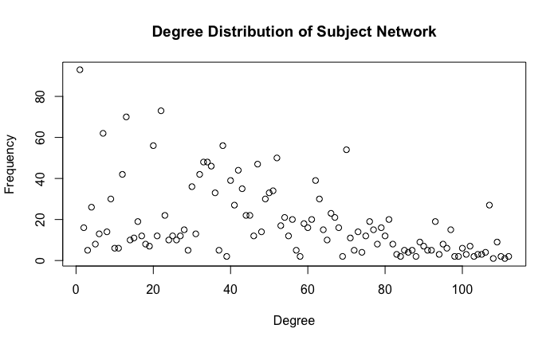

```r
# Basic network analysis
degree_distribution <- degree(graph_subjects)
plot(degree_distribution, main = "Degree Distribution of Subject Network", xlab = "Degree", ylab = "Frequency")
```

```r
# Plot the network
plot(graph_subjects, vertex.size = degree(graph_subjects), vertex.label.cex = 0.8, vertex.label.color = "blue", main = "Subject Co-occurrence Network")
```

[output not shown]

new

```r
library(tidyr)
library(dplyr)
library(igraph)

# Split the subjects and create a long format
data_business_long <- data_business %>%
  mutate(subject = strsplit(as.character(subject), ";")) %>%
  unnest(subject) %>%
  group_by(record_id) %>%
  filter(n() > 1)  # Ensure there are at least two subjects

# Create subject pairs
subject_pairs <- data_business_long %>%
  summarise(subject_combinations = combn(unique(subject), 2, simplify = FALSE)) %>%
  ungroup()
# Convert the list of subject combinations to a data frame
subject_pairs_flat <- do.call(rbind, subject_pairs$subject_combinations)
colnames(subject_pairs_flat) <- c("Subject1", "Subject2")
```

```r
# Count the frequency of each co-occurrence
edges_with_weights <- as.data.frame(subject_pairs_flat) %>%
  group_by(Subject1, Subject2) %>%
  summarise(co_occurrence_freq = n()) %>%
  ungroup()
# Create the graph with weighted edges
graph_subjects_weighted <- graph_from_data_frame(edges_with_weights, directed = FALSE)
```

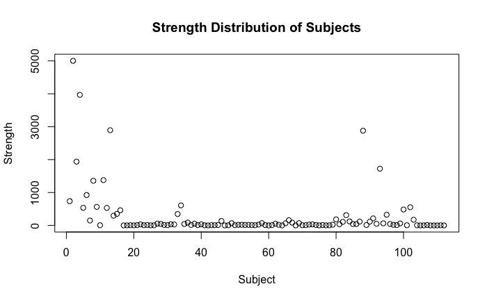

```r
# Analyze edge weights
E(graph_subjects_weighted)$weight <- edges_with_weights$co_occurrence_freq

# Calculate strength (weighted degree) of each node
strength_values <- strength(graph_subjects_weighted)

# Plot strength distribution
plot(strength_values, main = "Strength Distribution of Subjects", xlab = "Subject", ylab = "Strength")
```

[figure not shown]

```r
# Plot the network with edge width based on co-occurrence frequency
plot(graph_subjects_weighted, vertex.size=degree(graph_subjects_weighted),
     edge.width=E(graph_subjects_weighted)$weight,
     vertex.label.cex=0.7,
     main="Subject Co-occurrence Network (Weighted)")
```

```r
# Assuming 'graph_subjects_weighted' is your igraph object and it has an attribute 'name' for subjects

# Calculate strength (weighted degree) for each node
strength_values <- strength(graph_subjects_weighted, weights = E(graph_subjects_weighted)$weight)

# Create a data frame with subject names and their corresponding strength
subject_strength_df <- data.frame(
  subject = V(graph_subjects_weighted)$name,
  strength = strength_values
)

# Sort the data frame by strength in descending order
ordered_subjects <- subject_strength_df %>%
  arrange(desc(strength))

# Identify the subjects with the highest strength
top_subjects <- head(ordered_subjects, n = 10) # You can adjust 'n' based on how many top subjects you want to inspect
```

Insti level analysis

```r
data_business<- data_business_temp
```

```r
library(tidyr)
library(dplyr)
library(igraph)

# Assuming data_business is already loaded and has the 'institution' column
# Split the institutions and create a long format
data_business_long <- data_business %>%
  mutate(institution = strsplit(as.character(institution), ";")) %>%
  unnest(institution) %>%
  group_by(record_id) %>%
  filter(n() > 1)  # Ensure there are at least two institutions

# Create institution pairs
institution_pairs <- data_business_long %>%
  summarise(institution_combinations = combn(unique(institution), 2, simplify = FALSE)) %>%
  ungroup()
# Flatten the list of institution combinations and convert to a data frame
institution_pairs_flat <- do.call(rbind, unname(unlist(institution_pairs$institution_combinations, recursive = FALSE)))
```

[output not shown]

```r
# Count the frequency of each co-occurrence
edges_with_weights <- as.data.frame(institution_pairs_flat) %>%
  group_by(Institution1, Institution2) %>%
  summarise(co_occurrence_freq = n()) %>%
  ungroup()

# Create the graph with weighted edges
graph_institutions_weighted <- graph_from_data_frame(edges_with_weights, directed = FALSE)
```

Notes to self:

1. do the same thing for non business
2. Do like a pre - post analysis. See if we can do a before COPE, after COPE sort of arrangement?
3. Were the reasons before COPE different from the reasons after cope?
4. Can do ABDC vs non ABDC comparison of the QAP analysis